# PyLab_Linear_Transformations

```python
from __future__ import division
from sympy import *
init_printing(use_unicode=True)

import numpy as np

# Plots
import matplotlib.pyplot as plt

%matplotlib inline
plt.style.use('seaborn-white')

import warnings
warnings.filterwarnings("ignore")
```

[Home](https://hatefdastour.github.io/) / [Linear Algebra](https://hatefdastour.github.io/notes/Linear_Algebra/)

## Python Lab

- [**Getting Started with Python**](https://hatefdastour.github.io/notes/Getting_Started/Getting_Started.html)
- [**Chapter 1: Systems of Equations**](https://hatefdastour.github.io/notes/Linear_Algebra/PyLab_Systems_of_Equations.html)
- [**Chapter 2: Matrices**](https://hatefdastour.github.io/notes/Linear_Algebra/PyLab_Matrices.html)
- [**Chapter 3: Determinants**](https://hatefdastour.github.io/notes/Linear_Algebra/PyLab_Determinants.html)
- [**Chapter 4: Rn**](https://hatefdastour.github.io/notes/Linear_Algebra/PyLab_Rn.html)
- [**Chapter 5: Linear Transformations**](https://hatefdastour.github.io/notes/Linear_Algebra/PyLab_Linear_Transformations.html)
- [**Chapter 6: Complex Numbers**](https://hatefdastour.github.io/notes/Linear_Algebra/PyLab_Complex_Numbers.html)
- [**Chapter 7: Spectral Theory**](https://hatefdastour.github.io/notes/Linear_Algebra/PyLab_Spectral_Theory.html)
- [**Chapter 7: Markov Matrices**](https://hatefdastour.github.io/notes/Linear_Algebra/PyLab_Markov_Matrices.html)

**Python Lab: Linear Transformations**

## Special Linear Transformations in $\mathbb{R}^2$

### Rotation

Let $R_\theta:~\mathbb{R}^2 \to \mathbb{R}^2$ be a linear transformation given by\linebreak rotating vectors through an angle of $\theta$. Then the matrix $A$ of $R_\theta$ is given by \begin{align} \begin{bmatrix}\cos( \theta ) & -\sin( \theta )\\\sin( \theta ) & \cos( \theta )\end{bmatrix}. \end{align}

[figure not shown]

Let's define the following rotation function.

```python
def Rot(t):
    return Matrix([[np.cos(t) , -np.sin(t)], [np.sin(t) , np.cos(t)]])
```

```python
A = Matrix([[1], [1]])
A
```

$\displaystyle \left[\begin{matrix}1\\1\end{matrix}\right]$

```python
B = Rot(np.pi)*A
B
```

$\displaystyle \left[\begin{matrix}-1.0\\-1.0\end{matrix}\right]$

```python
C = Rot(np.pi/2)*A
C
```

$\displaystyle \left[\begin{matrix}-1.0\\1.0\end{matrix}\right]$

```python
D = Rot(-np.pi/2)*A
D
```

$\displaystyle \left[\begin{matrix}1.0\\-1.0\end{matrix}\right]$

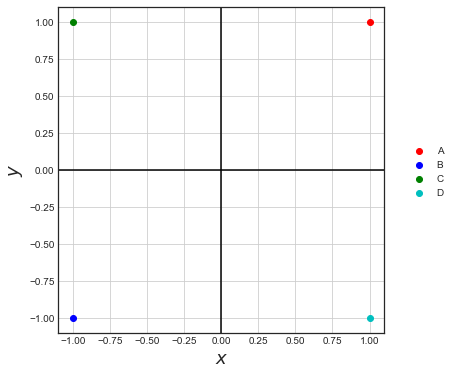

```python
fig, ax = plt.subplots(nrows=1, ncols=1, figsize=(6, 6))
_ = ax.scatter(A[0], A[1], marker='o', color='r', label='A')
_ = ax.scatter(B[0], B[1], marker='o', color='b', label='B')
_ = ax.scatter(C[0], C[1], marker='o', color='g', label='C')
_ = ax.scatter(D[0], D[1], marker='o', color='c', label='D')

_ = ax.set_xlabel('$x$', fontsize=18)
_ = ax.set_ylabel('$y$', fontsize=18)
_ = ax.legend(loc='best', bbox_to_anchor=(1.01, 0., 0.2, 0.6))
_ = ax.set_aspect('equal')
_ = ax.grid(True, which='both')
_ = ax.axhline(y=0, color='k')
_ = ax.axvline(x=0, color='k')
```

### Reflection

Let $Q_m: ~\mathbb{R}^2 \to \mathbb{R}^2$ a linear transformation given by reflecting vectors over the line $\vec{y} = m\,\vec{x}$ . Then the matrix of $Q_m$ is given by \begin{align} \frac{1}{1+m^2}\begin{bmatrix}1-m^2 & 2m\\2m &m^2-1\end{bmatrix} \end{align}

Now, we can define

```python
def Ref(m):
    return Matrix([[1-m**2 , 2*m], [2*m , m**2-1]])/(1+m**2)
```

**Example**: Let $Q_3: ~\mathbb{R}^2 \to \mathbb{R}^2$ denote reflection over the line $y = 3x$ . Then $Q_3$ is a linear transformation. Find the matrix of $Q_3$. Then, find $Q_3\begin{bmatrix}1 \\ 1\end{bmatrix}$.

```python
Q3 = Ref(3)
Q3
```

$\displaystyle \left[\begin{matrix}- \frac{4}{5} & \frac{3}{5}\\\frac{3}{5} & \frac{4}{5}\end{matrix}\right]$

```python
B = Q3*A
B
```

$\displaystyle \left[\begin{matrix}- \frac{1}{5}\\\frac{7}{5}\end{matrix}\right]$

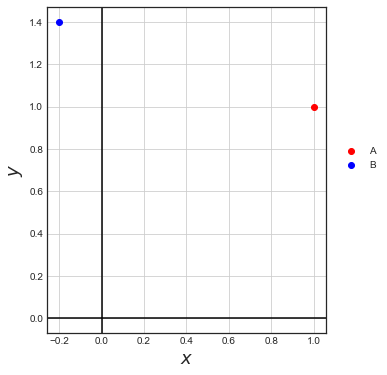

```python
fig, ax = plt.subplots(nrows=1, ncols=1, figsize=(6, 6))
_ = ax.scatter(A[0], A[1], marker='o', color='r', label='A')
_ = ax.scatter(B[0], B[1], marker='o', color='b', label='B')

_ = ax.set_xlabel('$x$', fontsize=18)
_ = ax.set_ylabel('$y$', fontsize=18)
_ = ax.legend(loc='best', bbox_to_anchor=(1.01, 0., 0.2, 0.6))
_ = ax.set_aspect('equal')
_ = ax.grid(True, which='both')
_ = ax.axhline(y=0, color='k')
_ = ax.axvline(x=0, color='k')
```